# PS5: rmarkdown and plotting

James Lee

February 19, 2023

# INFO201 PS5: rmarkdown and plotting

## Load an check data

*1. Load tidyverse*

```r
library(tidyverse)
```

*2. Load data. How many rows/columns do we have?*

```r
gm <- read_delim("data/gapminder.csv.bz2")
```

This data set contains 13055 observations and 25 variables.

*3. Print a small sample of data. Does it look OK?*

```r
gm %>%
  sample_n(10) %>%
  knitr::kable()
```

| iso3 | name | iso2 | region | sub-region | intermediate-region | time | totalPopulation | fertilityRate | lifeExpectancy | childMortality | youthFemaleLiteracy | youthMaleLiteracy | adultLiteracy | GDP_PC | accessElectricity | agriculturalLand | agricultureTractors | cerealProduction | fertilizerHa | co2 | greenhouseGases | co2_PC | pm2.5_35 | battleDeaths |
| --- | --- | --- | --- | --- | --- | --- | --- | --- | --- | --- | --- | --- | --- | --- | --- | --- | --- | --- | --- | --- | --- | --- | --- | --- |
| BHR | Bahrain | BH | Asia | Western Asia | NA | 2016 | 1425791 | 2.033 | 76.89900 | 7.4 | 98.85029 | 99.95573 | 97.06668 | 22272.9669 | 100.00000 | 86 | NA | NA | 458.88125 | 31693.881 | NA | 22.22898 | 100 | NA |
| SEN | Senegal | SN | Africa | Sub-Saharan Africa | Western Africa | 1976 | 5057378 | 7.258 | 44.64100 | 241.5 | NA | NA | NA | 1277.3904 | NA | 90450 | 380 | 730300 | 11.99639 | 1774.828 | 8527.00220 | 0.35094 | NA | NA |
| TJK | Tajikistan | TJ | Asia | Central Asia | NA | 1962 | 2236574 | 6.760 | 51.23700 | NA | NA | NA | NA | NA | NA | NA | NA | NA | NA | NA | NA | NA | NA | NA |
| ISR | Israel | IL | Asia | Western Asia | NA | 1966 | 2629000 | 3.802 | 72.28561 | 31.1 | NA | NA | NA | 11275.7158 | NA | 5250 | 11430 | 137100 | 123.61801 | 13597.236 | NA | 5.17202 | NA | NA |
| TGO | Togo | TG | Africa | Sub-Saharan Africa | Western Africa | 1979 | 2642696 | 7.254 | 51.79900 | 180.5 | NA | NA | NA | 659.0749 | NA | 30300 | 80 | 315228 | 1.56103 | 1382.459 | 9685.73620 | 0.52312 | NA | NA |
| STP | Sao Tome and Principe | ST | Africa | Sub-Saharan Africa | Middle Africa | 1979 | 93461 | 6.434 | 59.73100 | 90.1 | NA | NA | NA | NA | NA | 370 | NA | 450 | NA | 33.003 | 55.24492 | 0.35312 | NA | NA |
| PNG | Papua New Guinea | PG | Oceania | Melanesia | NA | 2007 | 6808514 | 4.156 | 61.14100 | 61.5 | NA | NA | NA | 1784.8530 | 23.18779 | 10400 | NA | 13242 | 75.84800 | 6120.223 | 9773.23840 | 0.89891 | NA | NA |
| LVA | Latvia | LV | Europe | Northern Europe | NA | 1975 | 2456130 | 1.960 | 68.92537 | NA | NA | NA | NA | NA | NA | NA | NA | NA | NA | NA | 52338.03790 | NA | NA | NA |
| KOS | NA | NA | NA | NA | NA | 1988 | 1791000 | 4.260 | 66.59512 | NA | NA | NA | NA | NA | NA | NA | NA | NA | NA | NA | NA | NA | NA | NA |
| MMR | Myanmar | MM | Asia | South-eastern Asia | NA | 1988 | 40085651 | 3.714 | 56.14400 | 119.6 | NA | NA | NA | 187.4661 | NA | 103730 | 12000 | 13647252 | 9.14028 | 4118.041 | 764834.98000 | 0.10273 | NA | NA |

With in the data set, there are some missing values in each varables, however, the overall data seems adequate.

## Descriptive statistics

*1. How many countries are there in the dataset? Analyze all three: iso3, iso2 and name.*

```r
gm %>%
  summarize(iso3_total = n_distinct(iso3), name_total = n_distinct(name),
            iso2_total = n_distinct(iso2)) %>%
  knitr::kable()
```

| iso3_total | name_total | iso2_total |
| --- | --- | --- |
| 253 | 250 | 249 |

There are 253 countries in iso3, 250 in name, and 249 in iso2

*2. If you did this correctly, you saw that there are more names than iso-2 codes, and there are even more iso3 -codes. What is going on? Can you find it out?*

*(a) Find how many names are there for each iso-2 code. Are there any iso-2 codes that correspond to more than one name? What are these countries?*

```r
gm %>%
  group_by(iso2) %>%
  summarize(num = n_distinct(name)) %>%
  arrange(desc(num))
```

```
## # A tibble: 249 × 2
##    iso2    num
##    <chr> <int>
##  1 <NA>      2
##  2 AD        1
##  3 AE        1
##  4 AF        1
##  5 AG        1
##  6 AI        1
##  7 AL        1
##  8 AM        1
##  9 AO        1
## 10 AQ        1
## # … with 239 more rows
```

There are 2 NA in iso2 comparably to name

*(b) Now repeat the same for name and iso3-code. Are there country names that have more than one iso3-code? What are these countries?*

```r
gm %>%
  group_by(name) %>%
  summarize(num = n_distinct(iso3)) %>%
  arrange(desc(num))
```

```
## # A tibble: 250 × 2
##    name             num
##    <chr>          <int>
##  1 <NA>               4
##  2 Afghanistan        1
##  3 Åland Islands      1
##  4 Albania            1
##  5 Algeria            1
##  6 American Samoa     1
##  7 Andorra            1
##  8 Angola             1
##  9 Anguilla           1
## 10 Antarctica         1
## # … with 240 more rows
```

```r
gm %>%
  filter(is.na(name)) %>%
  group_by(name) %>%
  filter(is.na(iso2)) %>%
  distinct(iso3)
```

```
## # A tibble: 4 × 2
## # Groups:   name [1]
##   iso3        name
##   <chr>       <chr>
## 1 CHANISL     <NA>
## 2 GBM         <NA>
## 3 KOS         <NA>
## 4 NLD_CURACAO <NA>
```

There are 4 NA in name comparably to iso3 and they are CHANISL, GBM, KOS, and NLD_CURACAO

*3. What is the minimum and maximum year in these data?*

Minimum year:

```r
gm %>%
  select(`time`) %>%
  filter(!is.na(time)) %>%
  min()
```

```
## [1] 1960
```

Maximum year:

```r
gm %>%
  select(`time`) %>%
  filter(!is.na(time)) %>%
  max()
```

```
## [1] 2019
```

## CO2 emissions

*1. How many missing co2 emissions are there for each year? Analyze both missing CO2 and co2_PC. Which years have most missing data?*

```r
gm %>%
  group_by(time) %>%
  select(time, co2, co2_PC) %>%
  summarize(CO2missings = sum(is.na(co2)), CO2_PCmissings = sum(is.na(co2_PC)))
```

```
## # A tibble: 61 × 3
##     time CO2missings CO2_PCmissings
##    <dbl>       <int>          <int>
##  1  1960          60             60
##  2  1961          60             60
##  3  1962          58             58
##  4  1963          57             57
##  5  1964          51             51
##  6  1965          51             51
##  7  1966          51             51
##  8  1967          51             51
##  9  1968          51             51
## 10  1969          51             51
## # … with 51 more rows
```

*2. Make a plot of total CO2 emissions over time for the U.S, China, and India. Add a few more countries of your choice. Explain what do you see.*

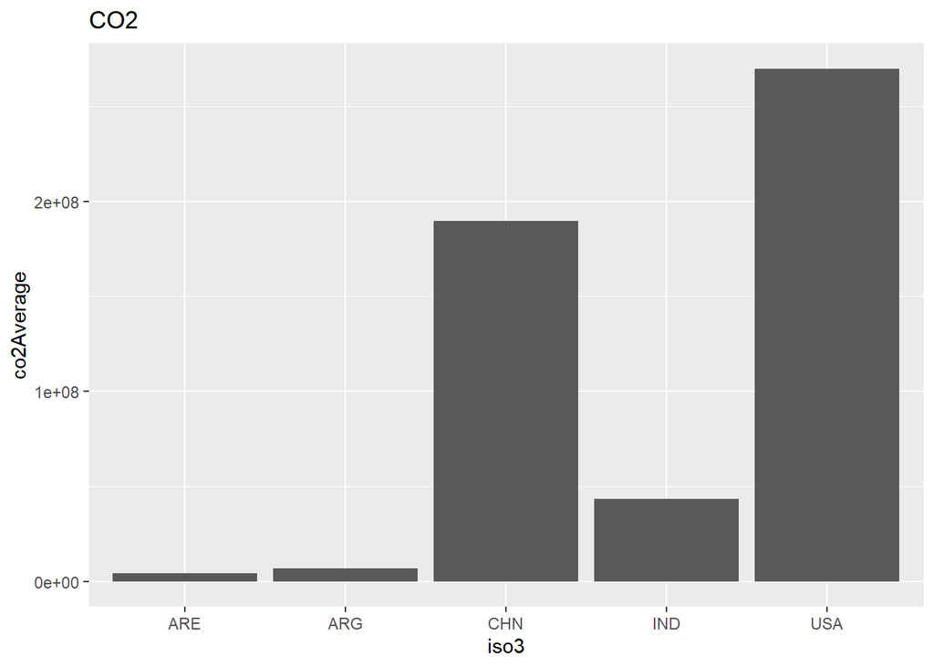

```r
co2Total <- gm %>%
  group_by(iso3, time) %>%
  filter(!is.na(co2), !is.na(name)) %>%
  mutate(co2Average = mean(co2)) %>%
  filter(iso3 == "USA" | iso3 == "CHN" | iso3 == "IND" | iso3 == "ARG" | iso3 == "ARE")

ggplot(data = co2Total) +
  geom_col(aes(x = iso3, y = co2Average)) +
  labs(title = "CO2")
```

Out of 5 countries, USA has the biggest CO2 emission.

*3. Now let’s analyze the CO2 emissions per capita (co2_PC). Make a similar plot of the same countries. What does this figure suggest?*

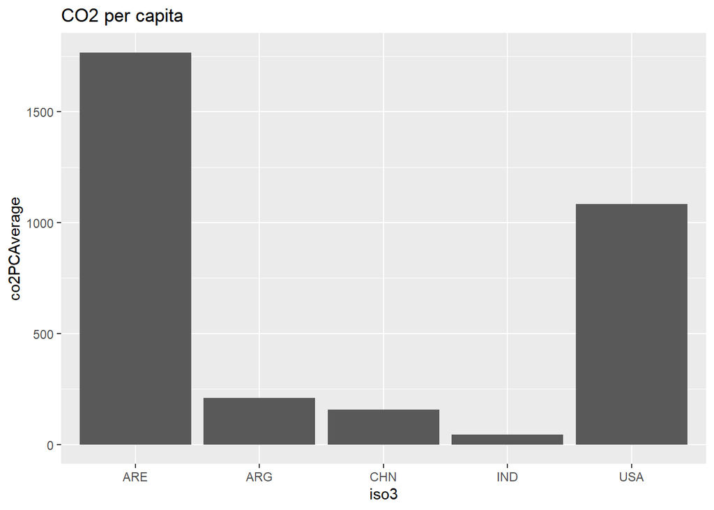

```r
co2PCTotal <- gm %>%
  group_by(iso3, time) %>%
  filter(!is.na(co2_PC), !is.na(name)) %>%
  mutate(co2PCAverage = mean(co2_PC)) %>%
  filter(iso3 == "USA" | iso3 == "CHN" | iso3 == "IND" | iso3 == "ARG" | iso3 == "ARE")

ggplot(data = co2PCTotal) +
  geom_col(aes(x = iso3, y = co2PCAverage)) +
  labs(title = "CO2 per capita")
```

For CO2_PC, United Arab Emirates has the biggest CO2 emission per capita, and USA is the second.

*4. Compute average CO2 emissions per capita across the continents (assume region is the same as continent). Comment what do you see.*

```r
gm %>%
  filter(time == '2016') %>%
  group_by(region) %>%
  filter(!is.na(co2_PC), !is.na(region)) %>%
  summarize(co2PCAverage = round(mean(co2_PC), 1)) %>%
  knitr::kable()
```

| region | co2PCAverage |
| --- | --- |
| Africa | 1.2 |
| Americas | 4.8 |
| Asia | 6.5 |
| Europe | 6.6 |
| Oceania | 4.6 |

In year 2016, the average CO2 emission per capita in each region was Africa: 1.2, Americas: 4.8, Asia: 6.5, Europe: 6.6, Oceania: 4.6.

*5. Make a barplot where you show the previous results–average CO2 emissions per capita across continents in 1960 and 2016*

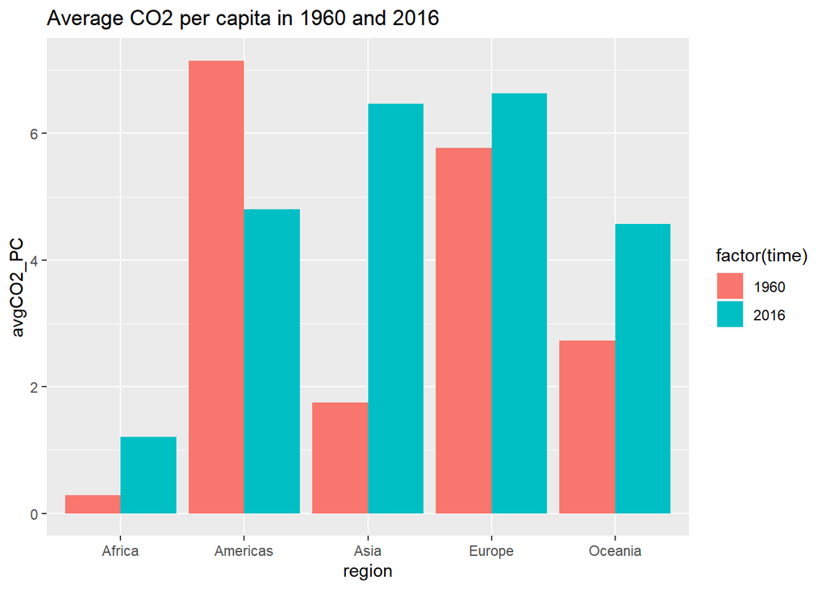

```r
gm %>%
  filter(!is.na(co2_PC), !is.na(region)) %>%
  filter(time == 1960 | time == 2016) %>%
  group_by(region, time) %>%
  mutate(avgCO2_PC = mean(co2_PC)) %>%
  ggplot(aes(x = region, y = avgCO2_PC, fill = factor(time))) +
  geom_bar(stat = 'identity', position = 'dodge') +
  labs(title = "Average CO2 per capita in 1960 and 2016")
```

*6. Which countries are the three largest, and three smallest CO2 emitters (in terms of CO2 per capita) in 2019 for each continent? (Assume region is continent).*

```r
gm %>%
  filter(time == "2019") %>%
  filter(!is.na(region)) %>%
  group_by(region) %>%
  arrange(co2_PC) %>%
  slice_head(n = 3) %>%
  select(region, name) %>%
  knitr::kable()
```

| region | name |
| --- | --- |
| Africa | Angola |
| Africa | Burundi |
| Africa | Benin |
| Americas | Aruba |
| Americas | Argentina |
| Americas | Antigua and Barbuda |
| Asia | Afghanistan |
| Asia | United Arab Emirates |
| Asia | Armenia |
| Europe | Albania |
| Europe | Andorra |
| Europe | Austria |
| Oceania | American Samoa |
| Oceania | Australia |
| Oceania | Fiji |

```r
gm %>%
  filter(time == "2019") %>%
  filter(!is.na(region)) %>%
  group_by(region) %>%
  arrange(co2_PC) %>%
  slice_tail(n = 3) %>%
  select(region, name) %>%
  knitr::kable()
```

| region | name |
| --- | --- |
| Africa | South Africa |
| Africa | Zambia |
| Africa | Zimbabwe |
| Americas | Venezuela (Bolivarian Republic of) |
| Americas | Virgin Islands (British) |
| Americas | Virgin Islands (U.S.) |
| Asia | Uzbekistan |
| Asia | Viet Nam |
| Asia | Yemen |
| Europe | Slovenia |
| Europe | Sweden |
| Europe | Ukraine |
| Oceania | Tuvalu |
| Oceania | Vanuatu |
| Oceania | Samoa |

## GDP per capita

*1. Make a scatterplot of GDP per capita versus life expectancy by country, using data for 1960. Make the point size dependent on the country size, and color those according to the continent. Feel free to adjust the plot in other ways to make it better. Comment what do you see there.*

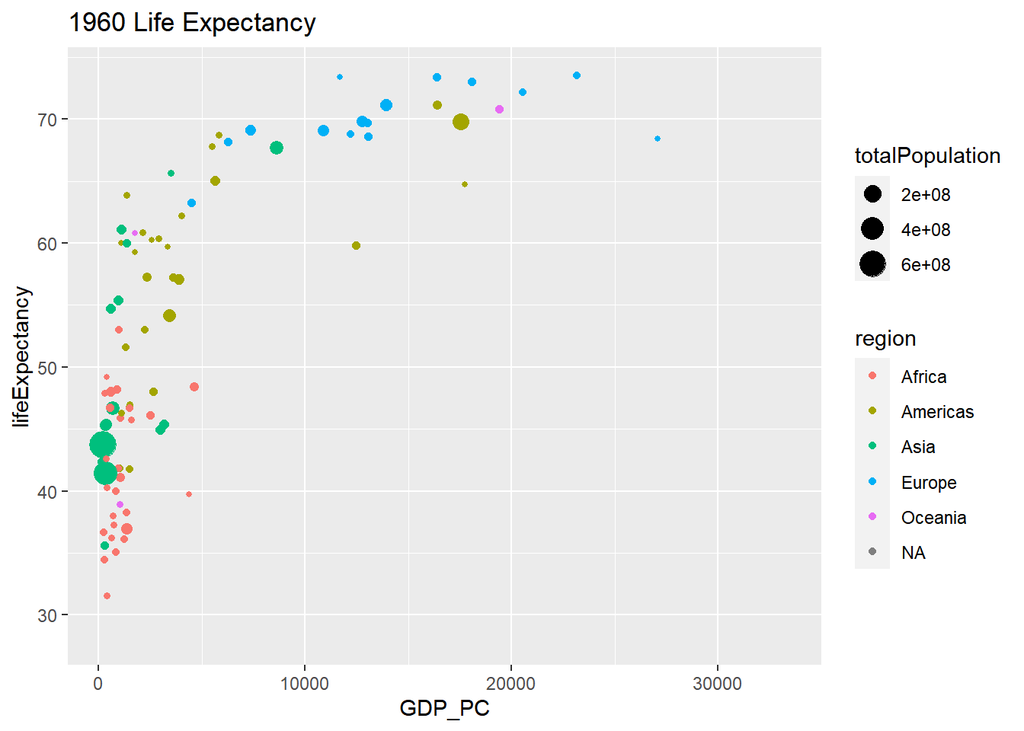

```r
sp1960 <- gm %>%
  filter(time == "1960")

ggplot(data = sp1960) +
  geom_point(mapping = aes(x = GDP_PC, y = lifeExpectancy, color = region,
                           size = totalPopulation)) +
  labs(title = "1960 Life Expectancy")
```

Analyzing the graph, Europe countries tend to have high life expectancies and GDP, where African countries mostly stays low in life expectancies and GDP.

*2. Make a similar plot, but this time use 2019 data only.*

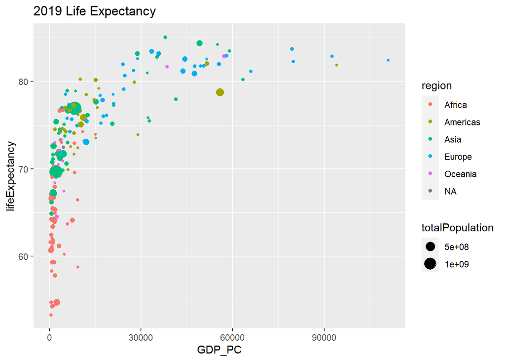

```r
sp2019 <- gm %>%
  filter(time == "2019")

ggplot(data = sp2019) +
  geom_point(mapping = aes(x = GDP_PC, y = lifeExpectancy, color = region,
                           size = totalPopulation)) +
  labs(title = "2019 Life Expectancy")
```

*3. Compare these two plots and comment what do you see. How has world developed through the last 60 years?*

*4. Compute the average life expectancy for each continent in 1960 and 2019. Do the results fit with what do you see on the figures? Note: here as average I mean just average over countries, ignore the fact that countries are of different size.*

```r
gm %>%
  group_by(region) %>%
  filter(time == "1960", !is.na(lifeExpectancy), !is.na(region)) %>%
  mutate(avgLe = mean(lifeExpectancy)) %>%
  summarize(averageLifeExpentancy = unique(avgLe)) %>%
  arrange(desc(averageLifeExpentancy))
```

```
## # A tibble: 5 × 2
##   region   averageLifeExpentancy
##   <chr>                    <dbl>
## 1 Europe                    68.3
## 2 Americas                  58.6
## 3 Oceania                   56.4
## 4 Asia                      51.6
## 5 Africa                    41.5
```

The result seems reasonable, Europe with highest life expectancy and Africa with the lowest life expectancy.

*5. Compute the average LE growth from 1960-2019 across the continents. Show the results in the order of growth. Explain what do you see. Hint: these data (data in long form) is not the simplest to compute growth. But you may want to check out the lag() function. And do not forget to group data by continent when using lag(), otherwise your results will be messed up! See https://faculty.washington. edu/otoomet/info201-book/dplyr.html#dplyr-helpers-compute.*

```r
gm %>%
  filter(!is.na(region), !is.na(lifeExpectancy), !is.na(time)) %>%
  filter(time %in% c("1960", "2019")) %>%
  group_by(region, time) %>%
  summarize(average = mean(lifeExpectancy)) %>%
  mutate(previous = lag(average, default = 0), growth = average - previous) %>%
  arrange(desc(growth))
```

```
## # A tibble: 10 × 5
## # Groups:   region [5]
##    region    time average previous growth
##    <chr>    <dbl>   <dbl>    <dbl>  <dbl>
##  1 Europe    1960    68.3      0     68.3
##  2 Americas  1960    58.6      0     58.6
##  3 Oceania   1960    56.4      0     56.4
##  4 Asia      1960    51.6      0     51.6
##  5 Africa    1960    41.5      0     41.5
##  6 Asia      2019    74.6     51.6   23.0
##  7 Africa    2019    64.1     41.5   22.6
##  8 Americas  2019    75.8     58.6   17.2
##  9 Oceania   2019    73.5     56.4   17.1
## 10 Europe    2019    79.4     68.3   11.1
```

Asia has the highest growth in life expectancy, where Europe had the lowest growth in life expectancy.

*6. Show the histogram of GDP per capita for years of 1960 and 2019. Try to put both histograms on the same graph, see how well you can do it!*

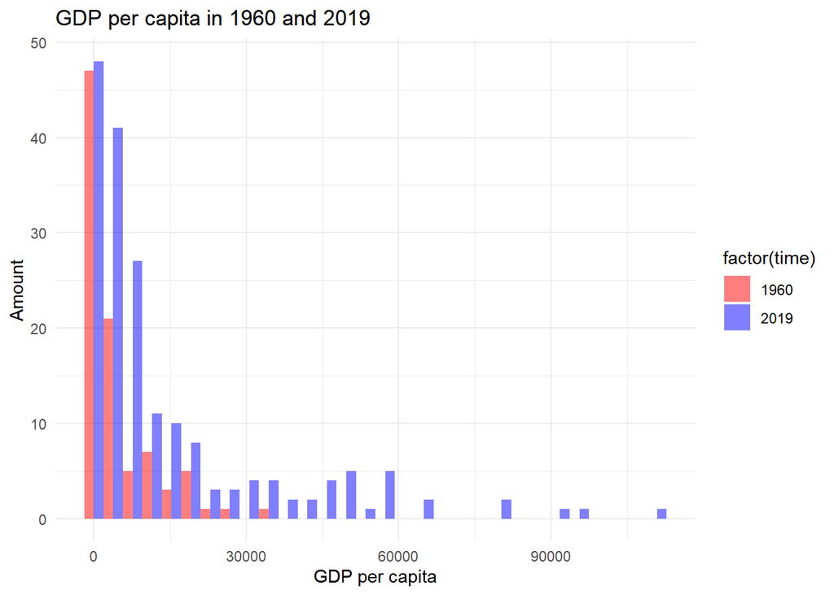

```r
gm %>%
  filter(!is.na(GDP_PC), time %in% c("1960", "2019")) %>%
  ggplot(aes(x = GDP_PC, fill = factor(time))) +
     geom_histogram(alpha = 0.5, position = "dodge", bins = 30) +
  scale_fill_manual(values = c("red", "blue"), labels =
                      c("1960", "2019")) +
  labs(x = "GDP per capita", y = "Amount", title = "GDP per capita in 1960 and 2019") +
  theme_minimal()
```

*7. What was the ranking of US in terms of life expectancy in 1960 and in 2019? (When counting from top.) Hint: check out the function rank()! Hint2: 17 for 1960.*

```r
gm %>%
  filter(time == "1960", !is.na(lifeExpectancy), !is.na(region)) %>%
  mutate(rank = rank(-lifeExpectancy)) %>%
  filter(name == "United States of America") %>%
  summarize(name, rank)
```

```
## # A tibble: 1 × 2
##   name                      rank
##   <chr>                    <dbl>
## 1 United States of America    17
```

```r
gm %>%
  filter(time == "2019", !is.na(lifeExpectancy), !is.na(region)) %>%
  mutate(rank = rank(-lifeExpectancy)) %>%
  filter(name == "United States of America") %>%
  summarize(name, rank)
```

```
## # A tibble: 1 × 2
##   name                      rank
##   <chr>                    <dbl>
## 1 United States of America    46
```

In 2019, the USA’s life expectancy rank is placed in 46. *8. If you did this correctly, then you noticed that US ranking has been falling quite a bit. But we also have more countries in 2019–what about the relative rank divided by the corresponding number of countries that have LE data in the corresponding year? Hint: 0.0904 for 1960.*

```r
countries2019 <- gm %>%
  filter(time == 2019, !is.na(lifeExpectancy), name != "") %>%
  summarise(num_countries_19 = n())

gm %>%
  filter(time == "2019", !is.na(lifeExpectancy), !is.na(region)) %>%
  mutate(relativeRank = rank(-lifeExpectancy) / countries2019) %>%
  filter(name == "United States of America") %>%
  summarize(name, relativeRank)
```

```
## # A tibble: 1 × 2
##   name                     num_countries_19
##   <chr>                               <dbl>
## 1 United States of America            0.378
```

Relative rank for the USA in 2019 is 0.378